# Курс по статистике: практикум урок 2

Альтшулер Евгений

# Текущая версия курса

## Список пакетов для установки

```r
# source('https://raw.githubusercontent.com/lapotok/biochem_statistics/master/2018/resources.R')
list.of.packages <- c('ggplot2', 'scales', 'plotly', 'openxlsx', 'httr', 'rvest', 'ggpubr', 'lattice', 'reshape2', 'repr', 'car', 'sinaplot', 'cowplot', 'dplyr', 'curl', 'dunn.test', 'ggforce', 'gridExtra', 'knitr', 'multcomp', 'drc', 'RColorBrewer', 'rmarkdown', 'boot', 'nlme', 'caret', 'ipred', 'e1071', 'ggpubr', 'PoweR', 'latex2exp', 'dimRed')
new.packages <- list.of.packages[!(list.of.packages %in% installed.packages()[,"Package"])]

if (!requireNamespace("BiocManager", quietly = TRUE))
    install.packages("BiocManager")
if (!("Biobase" %in% installed.packages()[,"Package"])) BiocManager::install("Biobase", version = "3.8")

if (length(new.packages) == 0) {
  message('No packages need to be installed.')
} else {
  message(paste(length(new.packages), 'packages need to be installed.'))
  install.packages(new.packages)
}
```

## Чем прекрасен R?

- бесплатный
- поддерживает Windows, Mac, Linux
- управление коммандами - проще следовать инструкциям из мануалов, причем удобно гуглить, начиная свой запрос со слов
  - r project
  - r language
  - r environment
  - https://rseek.org/
- язык программирования - значит можно автоматизировать действия

## Полезные источники по R

- https://cran.cnr.berkeley.edu/doc/contrib/Shipunov-rbook.pdf
- http://www.sthda.com/english/wiki/r-basics-quick-and-easy
- http://personality-project.org/r/
- http://mospolytech.ru/storage/b53b3a3d6ab90ce0268229151c9bde11/files/Mastitsky_and_Shitikov_2014.pdf
- https://rmarkdown.rstudio.com/lesson-1.html
- https://www.r-project.org/doc/bib/R-books.html
- https://cran.r-project.org/doc/contrib/Seefeld_StatsRBio.pdf

## Еще полезное по выбору статистических тестов и т.п.

- http://www.dataanalytics.org.uk/Data%20Analysis/Statistics/choosing-your-stats-test.htm
- https://www.ncbi.nlm.nih.gov/pmc/articles/PMC3116565/
- http://www.biochemia-medica.com/en/journal/20/1/10.11613/BM.2010.004
- https://serialmentor.com/dataviz/directory-of-visualizations.html
- http://www.wormbook.org/chapters/www_statisticalanalysis/statisticalanalysis.pdf

## Установка R/RStudio vs ONLINE

Официальные дистрибутивы (для всех систем, есть инструкции по установке)

- R - базовая версия (https://cran.r-project.org/)
- RStudio - оболочка для удобства (https://www.rstudio.com/products/rstudio/download/#download)

Еще бывает несколько онлайн-версий

- RNoteBook (https://rnotebook.io/)
- https://rdrr.io/snippets/
- http://www.tutorialspoint.com/execute_r_online.php

## Работа в RNotebook (jupyter notebook) vs RStudio

RNotebook

- https://rnotebook.io -> Create new R notebook -> File -> New notebook -> R
- ячейки: Code/Markdown
- Enter - новая строка, Shift+Enter - запуск ячейки

R, RStudio

- Консоль, комманды, возвращение к предыдущим
- Выполнение комманд из окна редактирования скриптов
- Окна объектов, картинок, помощи…

### Работа с переменными, вычисления

- математические операторы и функции (+, -, ^, *, log, abs, mean)
- переменные и как их называть

```r
my_variable = 1
MyVariable = 1
my.variable = 1
```

- присвоение значений переменным

```r
a = 1
a=1
a <- 1
a = "kjfhs"
a = 'kjfhs'
```

## Типы данных

```r
# number
my_number = 1

# character
my_char = "bla\tbla\nbla"
cat(my_char)

# boolean
my_bool1 = TRUE
my_bool2 = FALSE

# vector
my_vector1 = 1:20
# подмножество из вектора
my_vector1[2:4]
my_vector2 = c(1, 2, 30, 50, 100, 150)
# выполняем операцию сравнения
my_vector2 > 100
# выбираем значения, отвечающие критерию my_vector2 > 40
my_vector2[my_vector2 > 40]

# factor vs vector
# создаем вектор
age = c("young", "middle-aged", "old", "Old", "young", "middle-aged", "middle-aged")
age # просто перечень текстовых значений
# преобразуем в фактор (текстовые значения в коды, текст отображается лишь для простоты восприятия)
factor(age) # видим лишний уровень "Old", дублирующий "old"
age = c("young", "middle-aged", "old", "old", "young", "middle-aged", "middle-aged")
factor(age) # несортированный фактор
factor(age, levels=c("young", "middle-aged", "old"), ordered = TRUE) # levels задает возрастающий порядок уровней

# data.frame
head(iris) # iris - встроенный пример таблицы данных
```

### Таблица данных - учимся создавать подтаблицы

```r
# первая строка
iris[1,]
# первый столбец
iris[,1]

# пробуем доставать разные строки, столбцы и значения на основе разных критериев
iris[1:15,]
iris[,1:3]
iris[, c(1, 3, 5)]
iris[, c("Petal.Width", "Species")]
iris$Sepal.Length
iris$Sepal.Length[1:10]
iris$Species == "versicolor"
iris$Petal.Length[iris$Species == "versicolor"]
iris[iris$Species == "versicolor",]
iris$Sepal.Length > 7
iris[iris$Sepal.Length > 7,]
```

### Операции с векторами и таблицами

```r
# vectors
my_vector2 = 1:10
my_vector3 = (1:10)*10
1:10*10
(1:10)*10
my_vector2 + my_vector3
my_vector2 - 1
(my_vector2)^2
sum(my_vector2)
my_vector2 > 3

# tables
iris_subset = iris[1:10, 1:4]
apply(iris_subset, 1, sum) # суммируем построчно
apply(iris_subset, 2, sum) # суммируем поколоночно
iris_subset > 3.2
```

## Проверка нормальности распределения

Будем проверять распределение эмпирических данных (`vers`) и сгенерированных, соответствующих нормальному (`nd`) и ненормальному (`nnd`) распределению.

```r
vers = iris[iris$Species == "versicolor","Sepal.Length"]

# гистограмма
hist(vers)
?hist # справка
hist(vers, breaks = 20)

# кривая плотности вероятности распределения
density(vers)
plot(density(vers))
rug(vers)
stem(vers) # графический аналог описан тут http://www.dataanalytics.org.uk/Data%20Analysis/R%20Monographs/Dot%20Histogram.R

# пример нормального распределения
# для воспроизводимости генератора случайных чисел задаем "стартовое число"
set.seed(123)
nd = rnorm(100, mean=50, sd=5) # задаем желаемые параметры
hist(nd,breaks=20)
plot(density(nd))

# пример НЕнормального распределения
# для воспроизводимости генератора случайных чисел задаем "стартовое число"
set.seed(123)
nnd = rchisq(100, 20, 5) # задаем желаемые параметры
hist(nnd,breaks=20)
plot(density(nnd))

# критерий нормальности - shapiro.test
shapiro.test(vers)
st = shapiro.test(vers)
str(st)
st$p.value
st$p.value > 0.05 # TRUE => нормальное распределение
shapiro.test(nnd)$p.value # < 0.05 => ненормальное распределение

# визуальная оценка нормальности
qqnorm(vers) # нормально
qqline(vers)
qqnorm(nnd) # ненормально
qqline(nnd)
```

## Работаем с нормально распределенными данными

```r
# параметры нормального распределения
mean(vers)
sd(vers)

# z-трансформация
scale(vers)

# сами пишем функцию для проведения z-трансформации
# Версия 1 - длинная и поэтапная
z_transformation = function(x){
  step1 = mean(x)
  step2 = x - step1
  step3 = sd(x)
  step4 = step2/step3
  return(step4) # maybe just step4
}

# Версия 2 - лаконичная
z_transformation = function(x) (x-mean(x))/sd(x)
```

Кстати, нашел отличную [статью](https://www.mathsisfun.com/data/standard-deviation.html) про то, почему стандантартное отклонение не есть сумма отклонений и не сумма модулей, а именно корень из суммы квадратов.

## Трансформация данных в нормальные (***)

В пакете caret есть функция `preProcess`, в которой реализован ряд методов препроцессинга данных: “center”, “scale”, “BoxCox”, “YeoJohnson”, “expoTrans”, “range”, “knnImpute”, “bagImpute”, “medianImpute”, “pca”, “ica”, “spatialSign”, “zv”, “nzv”, “conditionalX”.

Из них “bagImpute”, “pca”, “ica”, “spatialSign” у меня не получилось использовать (например, “pca” и “ica” нужны для одновременного преобразования групп переменных, а не по одной), а что с “bagImpute” и “spatialSign” пошло не так я так и не понял…

Кроме того, из книги А.Б. Шипунова и др. “Наглядная статистика. Используем R!” я почерпнул еще несколько методов:

Логарифмическое: `log(data + 1)`. Если распределение скошено вправо, может дать нормальное распределение. Может также делать более линейными зависимости между переменными и уравнивать дисперсии. «Боится» нулей в данных, поэтому рекомендуется прибавлять единицу. Квадратного корня: `sqrt(data)`. Похоже по действию на логарифмическое. «Боится» отрицательных значений. Обратное: `1/(data + 1)`. Эффективно для стабилизации дисперсии. «Боится» нулей. Квадратное: `data^2`. Если распределение скошено влево, может дать нормальное распределение. Линеаризует зависимости и выравнивает дисперсии. Логит: `log(p/(1-p))`. Чаще всего применяется к пропорциям. Линеаризует так называемую сигмовидную кривую. Кроме логит-преобразования, для пропорций часто используют и арксинус-преобразование, `asin(sqrt(p))` Ряд перечисленных в книге преобразований не работает с отрицательными значениям. Поэтому я сначала шкалирую переменную `(scale(x))`, а затем добавляю 3, чтобы > 99% значений стали положительными, а затем применяю вышеозначенные дополнительные преобразования.

После всех трансформаций я снова провожу финальное шкалирование `(scale(x))`.

Как правило, метод BoxCox справляется лучше всего с задачей.

```r
library(caret)
library(ipred)

compareTransformations = function(var.nonscaled){

  if (is.data.frame(var.nonscaled)) var.nonscaled = var.nonscaled[[1]]
  if (is.matrix(var.nonscaled)) var.nonscaled = as.numeric(var.nonscaled)

  var.scaled = scale(var.nonscaled)
  len = length(var.nonscaled)

  # different types of transformations
  pp.list = c( "BoxCox", "YeoJohnson", "expoTrans", "range", "knnImpute", "medianImpute", "zv", "nzv", "conditionalX")

  dt = data.frame(transform=rep("scaled",len), data=var.scaled)

  for (pp in pp.list){
    pp.obj = preProcess(x=data.frame(x=var.nonscaled), method=pp)
    pp.res = predict(pp.obj, data.frame(x=var.nonscaled))
    dt = rbind(dt, data.frame(transform=rep(pp,len),data=scale(pp.res[,1])))
  }

  # log
  dt = rbind(dt, data.frame(transform=rep("log",len),data=scale(log(var.scaled+3))))
  # sqrt
  dt = rbind(dt, data.frame(transform=rep("sqrt",len),data=scale(sqrt(var.scaled+3))))
  # 1/(data+1)
  dt = rbind(dt, data.frame(transform=rep("1/(data+1)",len),data=scale(1/(var.scaled+1))))
  # data^2
  dt = rbind(dt, data.frame(transform=rep("data^2",len),data=scale(var.scaled^2)))
  # logit
  dt = rbind(dt, data.frame(transform=rep("logit",len),data=scale((var.scaled+3)/(1-(var.scaled+3)))))
  # arcsin
  dt = rbind(dt, data.frame(transform=rep("arcsin",len),data=scale(asin(scale(sqrt(var.scaled+3))/3))))

  dt.sh = c()
  dt.list = list()
  for (pp in unique(dt[,1])){
    dt.list[[pp]] = dt[dt[,1]==pp,2]
    dt.sh = c(dt.sh,sprintf("%.3f",shapiro.test(dt.list[[pp]])$p.value))
  }
  dt.sh.col = numeric(length(dt.sh))
  dt.sh.col[dt.sh>0.1] = "red"
  dt.sh.col[dt.sh<=0.1] = "gray"


  g = ggplot(dt,aes(x=transform, y=data)) +
    geom_boxplot(fill="cyan", size=.9) +
    geom_jitter(color="blue",alpha=0.3) +
    theme_bw(base_size = 16) +
    theme(axis.text.x = element_text(angle = 90, hjust = 1, vjust=0.2)) +
    geom_text(data=data.frame(), aes(x=1:length(unique(dt[,1])), y=rep(-4, length(unique(dt[,1]))), label=dt.sh),col=dt.sh.col, size=3) +
    coord_cartesian(ylim=c(-5,5))
  print(g)

  dt.list
}
```

Вот пример использования функции. На входе - переменная, имеющая гамма-распределение.

```r
set.seed(2016)
y = rgamma(200, 5)
transformedData = compareTransformations(y)
```

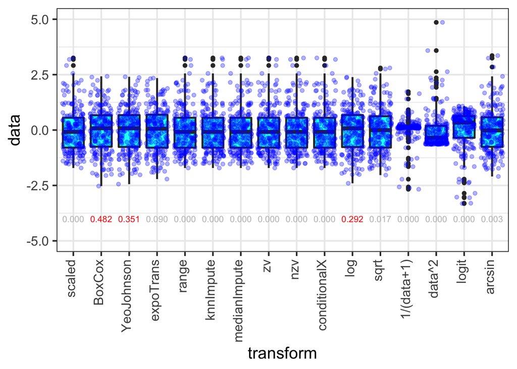

А вот другой пример.

```r
y = 1/rnorm(200, 40)*rf(200,40,5)
transformedData = compareTransformations(y)
```

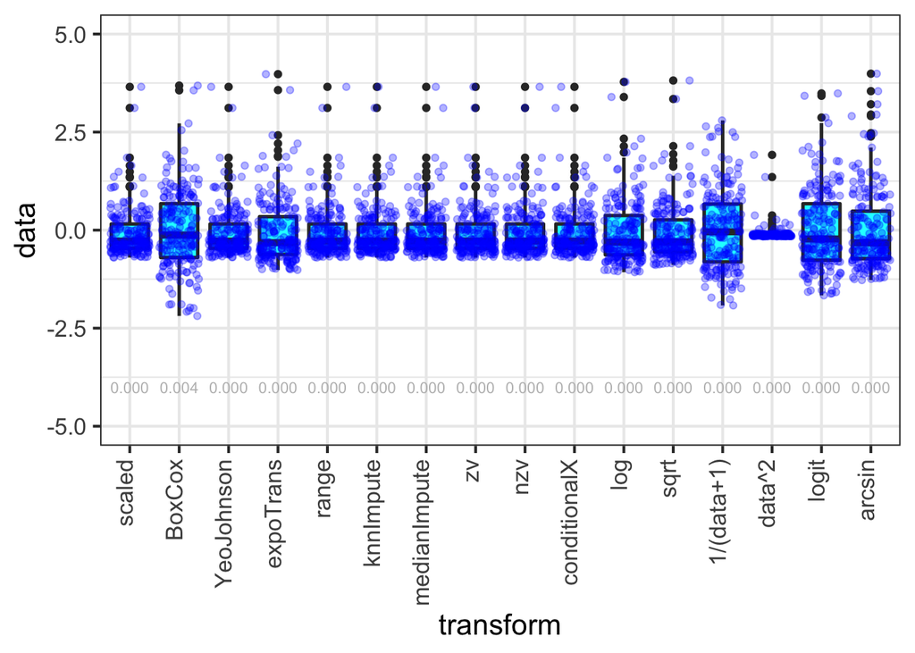

## T-test

Дополнительные ресурсы:

- https://r-analytics.blogspot.com/2012/03/t.html
- https://github.com/Lakens/perfect-t-test

### Непарный t-test - сравниваем объекты из двух групп (так чаще всего и бывает!)

Первым делом генерируем 3 нормально распределенных набора данных (выборки) по 30 элементов каждый

- А1 и А2 - элементы из одной генеральной совокупности (среднее 50, стандартное отклонение 5)
- B1 - элементы из другой генеральной совокупности (среднее 55, стандартное отклонение 5)

```r
set.seed(123) # задаем стартовое значения генератору случайных чисел
A1 = rnorm(30, m=50, 5)
A2 = rnorm(30, m=50, 5)
B1 = rnorm(30, m=55, 5)

# можно свести их в таблицу
tt_df = data.frame(A1 = A1, A2 = A2, B1 = B1)
head(tt_df)
```

```
        A1       A2       B1
1 47.19762 52.13232 56.89820
2 48.84911 48.52464 52.48838
3 57.79354 54.47563 53.33396
4 50.35254 54.39067 49.90712
5 50.64644 54.10791 49.64104
6 58.57532 53.44320 56.51764
```

Это была таблица в “широком” формате (столько столбцов, сколько групп/переменных). Для осуществления дальнейших манипуляций надо ее перевести в “длинный” формат (один столбец с названием групп, другой - со всеми значениями). Для этого можно использовать функцию `melt()` из пакета `reshape2`. Параметр `id.vars` будучи пустым говорит о том, что все колонки надо “сливать в одну”.

```r
library(reshape2)
tt_df_long = melt(tt_df, id.vars = c())
```

```
   variable    value
1        A1 47.19762
2        A1 48.84911
3        A1 57.79354
...
31       A2 52.13232
32       A2 48.52464
33       A2 54.47563
...
61       B1 56.89820
62       B1 52.48838
63       B1 53.33396
```

Первым делом хотелось бы посмотреть на данные глазами. Посмотрим на 2 типа графика: точечный график и боксплот в разных вариантах.

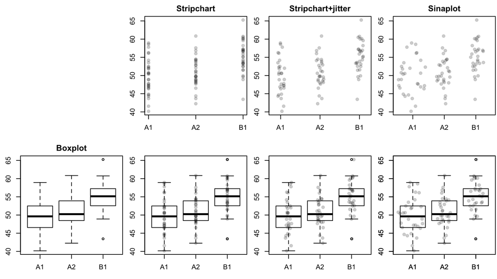

Боксплот - наиболее распространенный тип графика, но точки понятнее. Вот как строить эти графики.

```r
stripchart(value~variable, tt_df_long, v=T, main="Stripchart")
stripchart(value~variable, tt_df_long, v=T, method="jitter", main="Stripchart+jitter")
install.packages('sinaplot')
sinaplot(value~variable, tt_df_long, main="Sinaplot")
boxplot(value~variable, tt_df_long, main="Boxplot")
```

Но наиболее понятен был бы график, где есть и точки, и боксплот, и среднее со стандартным отклонением, и доверительный интервал. Для этого надо наслоить эти графики друг на друга.

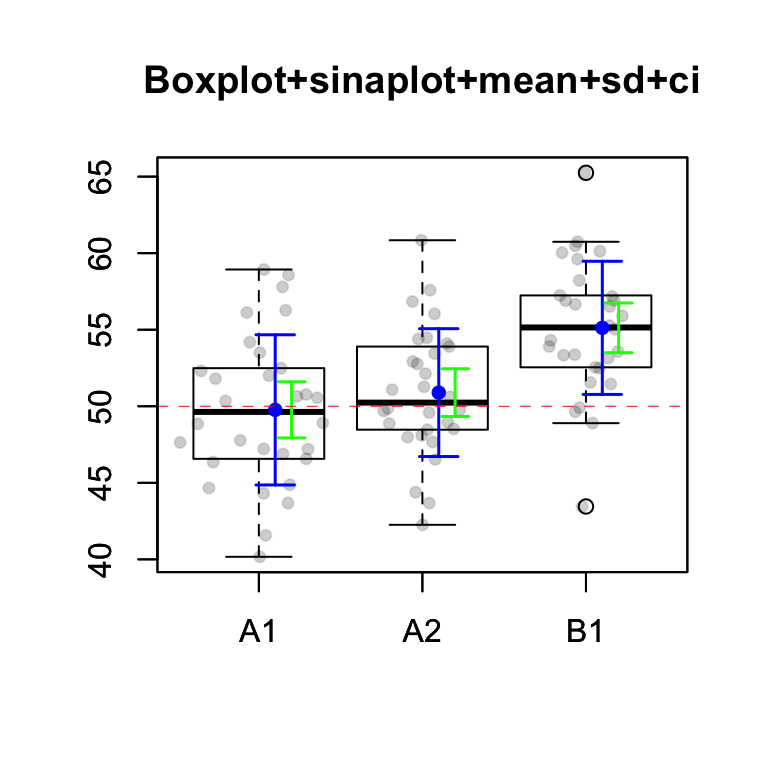

```r
boxplot(value~variable, tt_df_long, main="Boxplot+sinaplot+mean+sd+ci")
sinaplot(value~variable, tt_df_long, pch=21, col=alpha("black",0.1), bg=alpha("black",0.2), cex=.8, add=T)
means = aggregate(value~variable,tt_df_long, "mean")$value
sds = aggregate(value~variable,tt_df_long, "sd")$value
ci = aggregate(value~variable,tt_df_long, FUN=function(x) t.test(x)$conf.int)
ci_lower = ci$value[,1]
ci_upper = ci$value[,2]
vars = ci$variable
points(as.numeric(vars)+0.1, means, col="blue", pch=16)
arrows(as.numeric(vars)+0.1, means+sds, as.numeric(vars)+0.1, means-sds, code=3, angle=90, col="blue", lwd=1.5, len=0.1)
arrows(as.numeric(vars)+0.2, ci_lower, as.numeric(vars)+0.2, ci_upper, code=3, angle=90, col="green", lwd=1.5, len=0.07)
abline(h=50, col="red", lty="dashed", lwd=0.5)
```

Теперь мы представляем, как выглядит наше тестовое распределение, с которым мы будем работать. Перейдем к t-тесту, чтобы ответить, отличаются ли группы (могли ли они быть взяты из одной генеральной совокупности). Критерий Стьюдента можно применять только проверив нормальность (`shapiro.test()`) и гомогенность дисперсий (`bartlett.test()` или `leveneTest()` из пакета `car`).

```r
# критерий Стьюдента: нормальное распределение, одинаковые дисперсии
t.test(A1, B1, var.equal = T)
```

```
    Two Sample t-test

data:  A1 and B1
t = -4.4764, df = 58, p-value = 3.607e-05
alternative hypothesis: true difference in means is not equal to 0
95 percent confidence interval:
 -7.753392 -2.961849
sample estimates:
mean of x mean of y
 49.76448  55.12210
```

```r
# критерий Уэлча: нормальное распределение, может быть разные дисперсии
t.test(A1, B1)
```

```
    Welch Two Sample t-test

data:  A1 and B1
t = -4.4764, df = 57.18, p-value = 3.674e-05
alternative hypothesis: true difference in means is not equal to 0
95 percent confidence interval:
 -7.754124 -2.961117
sample estimates:
mean of x mean of y
 49.76448  55.12210
```

```r
# критерий Вилкоксона (Манна-Уитни): любое распределение, любые дисперсии (еще не проходили)
wilcox.test(A1, B1)
```

```
    Wilcoxon rank sum test

data:  A1 and B1
W = 184, p-value = 4.7e-05
alternative hypothesis: true location shift is not equal to 0
```

### Парный (=зависимый) - сравниваем измерения на тех же объектах, например, мыши до и после введения лекарства

- http://www.sthda.com/english/wiki/paired-samples-t-test-in-r

Есть соответствие между точками, сравниваем пары точек.

```r
library(reshape2)

# генерим пример данных
mice_w = data.frame(cbind(
  before = c(332.2, 345.5, 350.9, 352.7, 353.7, 356.9, 360.1, 365.2, 373, 381.4), # Weight of the mice before treatment
  after = c(345.1, 352.2, 360.3, 377.2, 382.9, 380, 373.9, 386, 402, 385.9), # Weight of the mice after treatment
  mice_id = 1:10
))
mice_w$mice_id = factor(mice_w$mice_id)
```

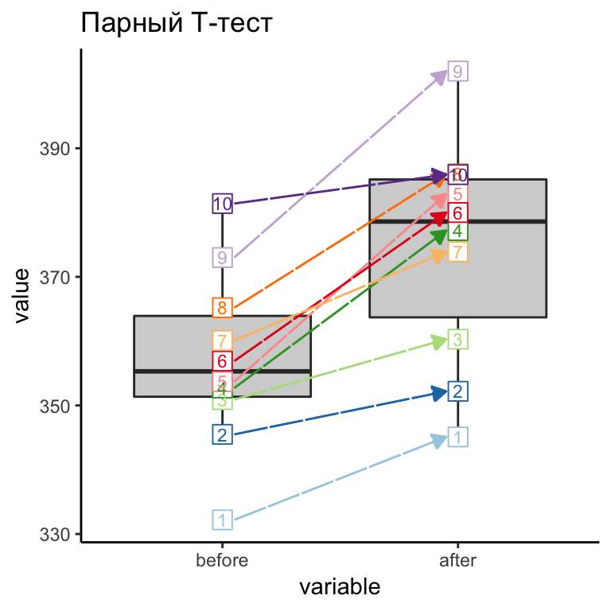

```r
# Compute t-test (way 1)
t.test(value~variable, mice_l, paired = TRUE)
```

```
    Paired t-test

data:  value by variable
t = -6.0387, df = 9, p-value = 0.0001931
alternative hypothesis: true difference in means is not equal to 0
95 percent confidence interval:
 -23.90446 -10.87554
sample estimates:
mean of the differences
                 -17.39
```

А если не учитывать порядок или если использовать непарный т-тест - будет плохо! .

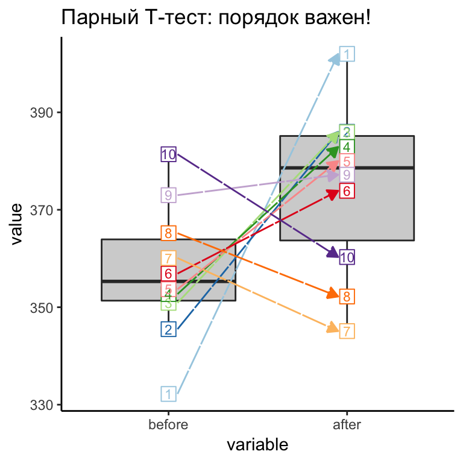

```r
t.test(mice_w$before, mice_w$after, paired=TRUE)$p.value
```

[output not shown]

```r
t.test(value~variable, mice_l)$p.value
```

```
[1] 0.02385308
```

У парного t-test есть модификации

- **two.sided** (нет оснований заранее предполагать, что before больше или меньше after)
- **less** (ожидаем, что что before больше after)
- **greater** (ожидаем, что что before больше after)

По умолчанию подразумевается two.sided, но мы это можем изменить, задав параметр `alternative`.

```r
t.test(before, after, paired = TRUE, alternative="two.sided")
```

### Мастер-функция для проверки нормальности распределения

http://www.sthda.com/english/wiki/normality-test-in-r

На входе - формула и таблица. Проверяется нормальность во всех группах 4-мя критериями

```r
# графики
il = melt(iris, id.vars = ("Species"))
library(ggpubr)
ggqqplot(il, "value", facet.by = c('Species', 'variable'))

# цифры разные критерии
library(PoweR)
?statcompute
normalityrejections<-(statcompute(21, diff, levels = c(0.05))$decision + statcompute(6, diff, levels = c(0.05))$decision + statcompute(2, diff, levels = c(0.05))$decision + statcompute(7, diff, levels = c(0.05))$decision)
tests = list()
tests[[21]] = "Shapiro-Wilk"
tests[[6]] = "D'Agostino-Pearson"
tests[[2]] = "Anderson-Darling"
tests[[7]] = "Jarque-Bera"
```

### Мастер-функция для проверки гомогенности дисперсии (***)

leveneTest, bartlett.test

### Функция проведения разных допустимых t-тестов

### Достоверность эффекта и сила эффекта

https://www.statisticshowto.datasciencecentral.com/hedges-g/

**Т-тест и Hedges’g**

```r
d <- cohen.d (y ~ factor (x), hedges.correction = TRUE)
```

A g of 1 indicates the two groups differ by 1 standard deviation, a g of 2 indicates they differ by 2 standard deviations, and so on. Standard deviations are equivalent to z-scores (1 standard deviation = 1 z-score).

Rule of Thumb Interpretation Cohen’s d and Hedges’ g are interpreted in a similar way. Cohen suggested using the following rule of thumb for interpreting results:

Small effect (cannot be discerned by the naked eye) = 0.2 Medium Effect = 0.5 Large Effect (can be seen by the naked eye) = 0.8 Cohen did suggest caution when using this rule of thumb. The terms “small” and “large” effects can mean different things in different areas. For example, a “small” reduction in suicide rates is invaluable, where a “small” weight loss may be meaningless.

### Доверительные интервалы и бутстреп

| Error bar type | Overlapping error bars | Non-overlapping error bars |
| --- | --- | --- |
| SD | no inference | no inference |
| SEM | sample means are not significantly different | no inference |
| CI | sample means may or may not be significantly different | sample means are significantly different |

```r
set.seed(012345)
x = rgamma(50, 3, 2)
hist(x)
plot(density(x))
shapiro.test(x)

abline(v=mean(x), col="red")
abline(v=median(x), col="blue")
abline(v=t.test(x)$conf.int, col="red", lty="dotted")

library(boot)
x.b = boot(data.frame(ind=rep(1, length(x)), val=x), function(d, i) median(d[i,"val"]), R=1000)
abline(v=boot.ci(x.b, type = 'basic')$basic[4:5], col="blue", lty="dotted")
```

## Дисперсионный анализ (ANOVA = ANalysis Of VAriance)

- https://r-analytics.blogspot.com/2013/01/blog-post.html
- http://personality-project.org/r/r.guide/r.anova.html#oneway
- http://www.sthda.com/english/wiki/one-way-anova-test-in-r

Сравнение средних в **нескольких** группах.

> **Вопрос**: Есть ли различия между группами? Какова вероятность, что такие значения можно случайно выбрать из одной генеральной совокупности?

Если межгрупповая изменчивость превышает внутригрупповую, то различия есть.

Варианты дисперсионного анализа:

- Однофакторный и многофакторный (число группирующих признаков)
- Параметрический и непараметрический (kruskal.test или приведение к нормальному распределению)

**Пример**.

Длины чашелистиков трех видов рода *Iris*.

Сначала посмотрим глазами на различия… *Не очень ясно, то ли отличаются, то ли нет*…

```r
library(scales)
boxplot(Sepal.Length ~ Species, iris) # формульный формат данных: зависимая переменная ~ независимая (группирующая, например, вид)
stripchart(Sepal.Length ~ Species, iris,
    vertical = TRUE, method = "jitter", add = TRUE, pch = 1, col = alpha('blue', 0.3))
```

Теперь проанализируем с помощью однофакторного дисперсионного анализа (фактор - вид).

```r
iris_aov = aov(Sepal.Length ~ Species, iris)
summary(iris_aov)
```

Видим, что F-значение >> 1, т.е. межгрупповая изменчивость больше внутригрупповой, т.е. различия между группами есть.

P-value << 0.05 - значит отклоняем нулевую гипотезу об отсутствии различий между группами. Т.е. достоверные различия между какими-то группами есть. Больше ничего не можем сказать.

Чтобы сказать, какие же группы от каких отличаются, нужны множественные попарные сравнения типа t-test. Но с поправкой на множественность сравнений (Bonferroni, Tukey…).

- https://r-analytics.blogspot.com/2013/10/blog-post.html
- https://r-analytics.blogspot.com/2013/10/blog-post_13.html
- https://r-analytics.blogspot.com/2013/10/blog-post_19.html
- https://www.slideshare.net/SergeyMastitsky/9-anova

```r
with(iris, pairwise.t.test(Sepal.Length,Species, p.adj="bonferroni"))

par(mar = c(4.5, 8, 4.5, 4.5))
plot(TukeyHSD(iris_aov), las=1)
```

## Advanced graphics: ggplot2 etc

https://www.rstudio.com/wp-content/uploads/2015/03/ggplot2-cheatsheet.pdf

- ggplot - основное окно, данные (эстетики и не-эстетики)
- элементы графика
  - точки geom_points
  - линии geom_line
  - полигоны geom_ribbon/geom_polygon
  - текст geom_text
  - geom_pointrange, geom_bar, geom_abline, geom_density, geom_histogram, geom_jitter, geom_sina, geom_rug, geom_violin, geom_segment
  - боксплоты
- элементы наслоения
- сдвиг
- полупрозрачность
- “пощупать” график с plotly
- facetting, multiple plots of different sizes
- par

## Boxplot и его типы

Читать: https://flowingdata.com/2012/05/15/how-to-visualize-and-compare-distributions/

- боксплот
- синаплот
- разбросы
  - доверительный интервал норм, т-распр, бутстреп
- значимость
- точки
- щупаем

Демонстрация

```r
ToothGrowth$dose <- as.factor(ToothGrowth$dose)
head(ToothGrowth)
library(ggplot2)
# просто точки
ggplot(ToothGrowth, aes(x=dose, y=len)) +
  geom_point() + theme_bw()

ggplot(ToothGrowth, aes(x=dose, y=len)) +
  geom_jitter(position=position_jitter(0.2)) + theme_bw()

# обычные boxplots
ggplot(ToothGrowth, aes(x=dose, y=len)) +
  geom_boxplot() + theme_bw()

# violin plots
ggplot(ToothGrowth, aes(x=dose, y=len)) +
  geom_violin(trim = FALSE) + theme_bw()

# mean +/- sd
ggplotly(ggplot(ToothGrowth, aes(x=dose, y=len)) +
  geom_jitter(position=position_jitter(0.2)) +
  stat_summary(fun.data="mean_sdl", geom="pointrange", color="red") +
  theme_bw())

# boxplot + jitter + ...
# mean_sdl
tinterval = function(x) data.frame(ymin=t.test(x)$conf.int[1], ymax=t.test(x)$conf.int[2])
ggplot(ToothGrowth, aes(x=dose, y=len)) +
  geom_boxplot() +
  geom_jitter(position=position_jitter(0.2), col=alpha("black",0.3), size=3) +
  stat_summary(fun.data="mean_sdl", geom="pointrange", color="red", size=1.5) +
  stat_summary(fun.data="tinterval", geom="linerange", color="green", size=3) +
  theme_bw()

g = ggplot(ToothGrowth, aes(x=dose, y=len)) +
  geom_boxplot() +
  geom_jitter(position=position_jitter(0.2), col=alpha("black",0.3), size=3) +
  stat_summary(fun.data="mean_sdl", geom="pointrange", color="red", size=4) +
  stat_summary(fun.data="tinterval", geom="linerange", color="green", size=2) +
  theme_bw()

ggplotly(g)
```

- if else, ifelse, logical indexing, %in%
- subset

### Циклы

- for
- while
- foreach
- until

### Параллельное вычисление

- aggregate, apply, by
- lambda-функции
- векторизованные вычисления

```r
# Вариант №1:
Var = function(x) ((sum((x-mean(x))^2))/(length(x)-1))

# Вариант №2:
cicledVar = function(x){
  Xavr=mean(x)
  a <- 0
  for (i in 1:length(x))
    a <- a+(x[i]-Xavr)^2
  cicledVar <- a/(length(x)-1)
  return(cicledVar)
}

dat = rnorm(100000, 50, 3)
system.time(for (i in 1:1000) Var(dat))
system.time(for (i in 1:1000) cicledVar(dat))
```

### Примеры автоматизации

#### Автоматизация расчетов на примере `shapiro.test()`

Надо проверить нормальность распределения каждой из переменных (их 4) для каждого вида ирисов (их 3).

Если не автоматизировать, то надо написать $4\cdot3=12$ команд следующего вида (заменяя название вида и переменной)

```r
shapiro.test(iris[iris$Species == 'versicolor', 'Petal.Length'])$p.value
```

```
[1] 0.1584778
```

Основа автоматизации - циклы. Цикл `for` - это когда для каждого элемента из набора производится какое-то действие.

*Циклы необходимы тогда, когда нужны последовательные вычисления. Альтернативой являются функции для параллельного вычисления (apply/sapply/tapply/vapply/lapply). В последнем случае циклов желательно избегать.*

Еще почитать про циклы

- https://www.r-bloggers.com/how-to-write-the-first-for-loop-in-r/
- https://habr.com/company/microsoft/blog/320232/

```r
# набор
numbers = 1:10
# действие - печать элемента
for (i in numbers){
  print(i)
}
# другое возможное действие - возведение в степень
for (i in numbers){
  print(i^2)
}
```

Теперь применим знание о циклах для нашей задачи. Распечатаем `shapiro.test(...)$p.value` для всех переменных одного вида.

```r
# переменные
colnames(iris)
```

```
[1] "Sepal.Length" "Sepal.Width"  "Petal.Length" "Petal.Width"
[5] "Species"
```

```r
# переменная Species нам не нужна
colnames(iris)[1:4] # аналогичного эффекта можно добиться так: colnames(iris)[-5]
```

```
[1] "Sepal.Length" "Sepal.Width"  "Petal.Length" "Petal.Width"
```

```r
my_vars = colnames(iris)[1:4]

for (var_i in my_vars){
  print(var_i)
  print(shapiro.test(iris[iris$Species == 'versicolor', var_i])$p.value)
}
```

```
[1] "Sepal.Length"
[1] 0.464737
[1] "Sepal.Width"
[1] 0.3379951
[1] "Petal.Length"
[1] 0.1584778
[1] "Petal.Width"
[1] 0.0272778
```

Чтобы два раза не печатать `print()`, а скомбинировать два значения (имя переменной и значение p-value), можно использовать функцию `paste()`. А еще можно использовать функцию `round()` для округления значений.

```r
my_var_name = "MyVariableName"
my_pvalue = 0.05235125413524
print(paste(my_var_name, round(my_pvalue, 3)))
```

```
[1] "MyVariableName 0.052"
```

Аналогично распечатаем `shapiro.test(...)$p.value` для одной переменной всех видов.

```r
# виды
iris$Species # перечень всех значений переменной
unique_species = unique(iris$Species) # найдите как достать уникальные значения вектора/фактора

for (sp_i in unique_species){
  rounded = round( shapiro.test(iris[iris$Species == sp_i, 'Petal.Length'])$p.value, 3 )
  print(paste(sp_i, rounded))
}
```

```r
for (sp_i in unique(iris$Species)) print(paste(sp_i, round( shapiro.test(iris[iris$Species == sp_i, 'Petal.Length'])$p.value, 3 )))
```

```
[1] "setosa 0.055"
[1] "versicolor 0.158"
[1] "virginica 0.11"
```

Теперь мы готовы оценить нормальность всех признаков для всех видов. Но сначала создадим матрицу размерностью в *ЧислоВидов*ЧислоПеременных*, куда будем помещать значения.

```r
# считаем число видов
Nsp = length(unique(iris$Species))
# считаем число признаков
Nvar = ncol(iris)-1
# создаем пустую матрицу размерностью ЧислоВидов*ЧислоПеременных
my_matrix = matrix(data=NA, nrow=Nsp, ncol = Nvar) # строки-виды, колонки-признаки
# подписываем названия колонок и строк
colnames(my_matrix) = colnames(iris)[1:4]
rownames(my_matrix) = unique(iris$Species)
```

Теперь в приготовленную матрицу закидываем значения, которые в цикле получим.

```r
for (sp_i in rownames(my_matrix)){
  for(var_i in colnames(my_matrix)){
    my_matrix[sp_i, var_i] = shapiro.test(iris[iris$Species == sp_i, var_i])$p.value
  }
}
# округляем
round(my_matrix, 3)
```

```
           Sepal.Length Sepal.Width Petal.Length Petal.Width
setosa            0.460       0.272        0.055       0.000
versicolor        0.465       0.338        0.158       0.027
virginica         0.258       0.181        0.110       0.087
```

```r
# выясняем, кто распределен нормально
my_matrix > 0.05
```

```
           Sepal.Length Sepal.Width Petal.Length Petal.Width
setosa             TRUE        TRUE         TRUE       FALSE
versicolor         TRUE        TRUE         TRUE       FALSE
virginica          TRUE        TRUE         TRUE        TRUE
```

Итак, вместо множества однообразных команд мы смогли написать программу, которая автоматически может проверить нормальность распределения любого количества признаков у любого количества видов. А потом эти данные можно наглядно визуализовать в виде `heatplot`.

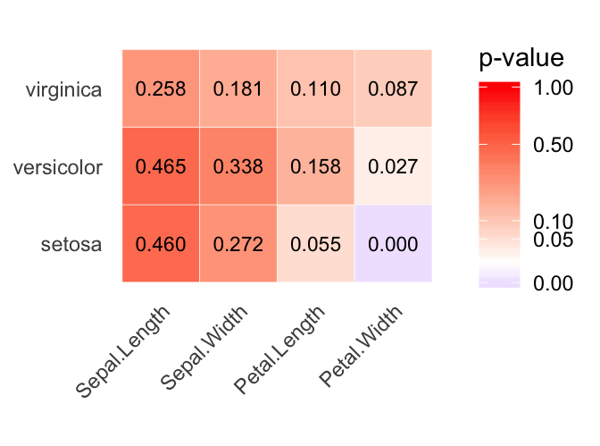

## Работа с файлами

### Ввод в текстовом виде

```r
weight_of_my_students = c(65, 54, NA, 67, 45, 78) # NA - Not Available
```

### Copy-paste из экселя

```r
my_table = read.table(text="сюда    вставлять   таблицу") # далее пример
my_table = read.table(text="v1  v2
1   2
11  22
111 222
1.3 7
4   NA", header=TRUE, dec=".") # header=TRUE если есть названия переменных, dec="." устанавливает точку десятичным разделителем
# анализируем структуру открытой таблицы
str(my_table)
```

### Импорт из Excel (XLSX и т.п.)

- Найти файл и сохранить найденное название в переменную - file.choose()
- Узнать/сменить рабочую директорию - getwd() и setwd()
- Записать в переменную имя+путь файла (опциально)
- Установить новый пакет - install.packages(’openxlsx’)
- Загрузить пакет - library(openxlsx)
- Можно импортировать экспортированные таблицы из форматов TXT, CSV, DAT (`read.table()`, `read.csv()`…)
- Собственно открыть файл
- Полезные опции импорта (могут немного отличаться для разных команд)
  - `sheet` (название листа XLSX, который будет импортирован)
  - `header=TRUE` (если есть названия переменных в первой строке)
  - `na.strings = с("", "NA", "Na", "na", "?")` (сразу говорим, как выглядят пропущенные данные)
  - `dec=","` (задаем десятичный разделитель - как правило `","` для русской локализации операционных систем)
- Применить функцию `toupper()` ко всем строковым переменным, чтобы ликвидировать разницу в регистрах
- Сразу после импорта полезно задать классы переменных функцией `colClasses()` (если это не было сделано при чтении файла)
- Затем просмотреть таблицу на предмет ошибок
- Для ранжированных факторов (например, возраст: “молодой”, “зрелый”, “старый”) нужно задать порядок уровней командой `factor()`, например `factor(age, ordered=T, levels=c('young', 'middle-aged', 'old'))`

```r
install.packages('openxlsx') # если этот пакет еще не установлен
library(openxlsx)

getwd() # а setwd чтобы перейти в другую папку
my_filename1 = file.choose() # выбираем в окошке
my_filename2 = "/Users/lapotok/Dropbox/study/biochem_statistics/bad_data_example.xlsx"# '/Users/some_directory/my_file.xlsx'

my_xlsx = read.xlsx(my_filename2)
str(my_xlsx)
```

### Парсинг - 1

Парсинг - считывание и распознавание файла в каком-то хитром формате с целью выудить определенные данные оттуда и перевести в удобный нам формат.

```
Labsystems GENESIS Plate Data REV3.05
C:\genlite\protocol\450\05MAY12W.001
MULTISKAN EX    PRIMARY EIA V. 2.1-0
05 May 2012   18:03:27
c:\genlite\protocol\450.prt
0 12
1



450
00:00:00
0
[DATA 0001]
 2.692 2.889 1.086 1.088 1.380 1.301 1.411 1.357 1.306 1.324 1.025 0.962
 3.030 3.117 1.048 1.007 1.319 1.154 1.304 1.086 1.168 1.158 0.714 0.723
 2.839 2.882 0.798 0.845 0.982 0.964 1.003 1.059 0.984 1.052 0.297 0.268
 1.805 1.986 0.361 0.371 0.543 0.530 0.615 0.616 0.493 0.571 0.114 0.122
 0.561 0.573 0.117 0.124 0.182 0.164 0.207 0.196 0.152 0.185 0.065 0.068
 0.188 0.156 0.077 0.077 0.086 0.083 0.092 0.094 0.078 0.085 0.066 0.055
 0.088 0.093 0.065 0.052 0.056 0.055 0.055 0.060 0.056 0.055 0.050 0.053
 0.053 0.055 0.055 0.064 0.059 0.060 0.050 0.053 0.051 0.052 0.052 0.050
```

- Полезные функции: read.table, scan, file+readLines+close, strsplit, paste, substr
- Regular expressions (grep, gsub)

### Парсинг - 2

Вариант 1 - читаем построчно, распознаем

```r
file_name = "/Users/lapotok/Dropbox/study/biochem_statistics/05MAY12W.001.fia.txt"
file_con = file(file_name)
file_contents = readLines(file_con)
close(file_con)

print(file_contents)

for(i in 15:22) {
  print(strsplit(file_contents[i], ' ')) # объект формата список
}

for(i in 15:22) print(strsplit(file_contents[i], ' ')[[1]])

my_values = c()
for(i in 15:22) my_values = c(my_values, as.numeric(strsplit(file_contents[i], ' ')[[1]][2:13]))
my_values
my_matrix = matrix(my_values, nrow=8, ncol=12, byrow = TRUE)
my_matrix
```

### Парсинг - 3

```r
# а можно и быстрее!
scan(file_name, skip=14)
matrix(scan(file_name, skip=14), nrow=8, byrow=T)

# а теперь все файлы *.fia.txt в директории!
my_fias = list()
my_dir = "/Users/lapotok/Dropbox/study/biochem_statistics/"
dir(my_dir)
dir(my_dir, pattern="*.fia.txt") # *.fia.txt - пример регулярного выражения

# цикл - основа автоматизации
my_file_example = "05MAY12W.001.fia.txt"
my_dir
paste(my_dir, my_file_example)
paste(my_dir, my_file_example, sep="")

for (my_file in dir(my_dir, pattern="*.fia.txt")) print(matrix(scan(my_file, skip=14), nrow=8, byrow=T))

for (my_file in dir(my_dir, pattern="*.fia.txt")) my_list[[my_file]] = matrix(scan(my_file, skip=14), nrow=8, byrow=T)
my_list
```

### Импорт таблицы с сайта (HTML) - 1

Код:

```
<html>
  <head>
  </head>
  <body>
    <table id="results" class="someclass">
      <tr>
        <th>Заголовок 1</th><th>Заголовок 2</th>
      </tr>
      <tr>
        <td>Ячейка 1.1</td><td>Ячейка 1.2</td>
      </tr>
      <tr>
        <td>Ячейка 2.1</td><td>Ячейка 2.2</td>
      </tr>
    </table>
  </body>
</html>
```

Результат:

| Заголовок 1 | Заголовок 2 |
| --- | --- |
| Ячейка 1.1 | Ячейка 1.2 |
| Ячейка 2.1 | Ячейка 2.2 |

### Импорт таблицы с сайта (HTML) - 2

```r
library(httr)
library(rvest)

# локальный файл
file_name = "/Users/lapotok/Dropbox/study/biochem_statistics/parkrun.html.txt"
my_html = read_html(file_name)

# простая закачка страницы с сайта
url = 'http://www.parkrun.ru/severnoetushino/results/weeklyresults/?runSeqNumber=248'
my_html = read_html(url) # Ошибка! Ограничение на скачивание

# хитрые случаи
url = 'http://www.parkrun.ru/severnoetushino/results/weeklyresults/?runSeqNumber=248'

# use_proxy - если надо в обход блокировки, в примере - прокси для TorBrowser
# add_headers - если надо "притвориться браузером", как в данном случае
w <- GET(url,
          use_proxy("socks5://localhost:9150"),
          add_headers('user-agent' = 'Gov employment data scraper ([[your email]])'))
my_html = read_html(w)
res = html_node(my_html, 'table#results')
tbl = html_table(res)
```

### Импорт GPS треков GPX (XML)

```
<?xml version="1.0" encoding="UTF-8"?>
<gpx
  version="1.1"
  creator="Runkeeper - http://www.runkeeper.com"
  xmlns:xsi="http://www.w3.org/2001/XMLSchema-instance"
  xmlns="http://www.topografix.com/GPX/1/1"
  xsi:schemaLocation="http://www.topografix.com/GPX/1/1 http://www.topografix.com/GPX/1/1/gpx.xsd"
  xmlns:gpxtpx="http://www.garmin.com/xmlschemas/TrackPointExtension/v1">
<wpt lat="37.778259000" lon="-122.391386000">
  <ele>3.4</ele>
  <time>2016-06-17T23:41:03Z</time>
  <extensions>
    <gpxtpx:TrackPointExtension>
      <gpxtpx:hr>171</gpxtpx:hr>
    </gpxtpx:TrackPointExtension>
  </extensions>
</wpt>
<wpt lat="37.778194000" lon="-122.391226000">
  <ele>3.4</ele>
  <time>2016-06-17T23:41:13Z</time>
  <extensions>
    <gpxtpx:TrackPointExtension>
      <gpxtpx:hr>171</gpxtpx:hr>
    </gpxtpx:TrackPointExtension>
  </extensions>
</wpt>
...
</gpx>
```

```r
# вариант со скачиванием из интернета
fl = read_html('https://gist.githubusercontent.com/cly/.../sample.gpx')

# вариант с локальным файлом
fl = read_html("/Users/lapotok/Dropbox/study/biochem_statistics/gpx.txt")
html_attr(html_nodes(fl,'wpt'), 'lat')
html_text(html_nodes(fl,'ele'))
html_text(html_nodes(fl,'time'))
```

- Импорт из других форматов (HTML, XML, кастомные форматы выдачи приборов и т.п.) - можно найти пакеты/советы на форумах/написать самому

### Задания

- Пропарсить XML (RSS с сайта кафедры - http://biochem.bio.msu.ru/sitemap.xml)

```r
xml_url = 'http://biochem.bio.msu.ru/sitemap.xml'

fl = read_html(xml_url)
html_nodes(fl,'loc')
html_nodes(fl,'lastmod')
html_text(html_nodes(fl,'lastmod'))

df = data.frame(
  loc = html_text(html_nodes(fl,'loc')),
  lastmod = html_text(html_nodes(fl,'lastmod'))
)
```

## Регрессия: 5 PL curve

### DRC

```r
copypasted = "conc  1   2   3
300.00  1250233 1192534 1159014
100.00  639743  627215  639018
33.33   186238  182822  189122
11.11   44873   42599   45131
3.70    10219   9413    10251
1.23    3594    3723    3493
0.41    2106    NA  2137
0.00    1575    1880    1633
0.00    1836    1724    1298"

rd <- read.table(header=TRUE, row.names=NULL, sep="\t", text=copypasted)

suppressMessages(require(drc))
suppressMessages(require(reshape2))
suppressMessages(require(ggplot2))
suppressMessages(require(latex2exp))

colnames(rd) = c("conc", 1:(ncol(rd)-1))
ld = melt(rd, id.vars=c("conc"))
m = drm(value ~ conc, data = subset(ld, select = c("conc", "value")), fct=LL.5())
m = suppressWarnings(suppressMessages(boxcox(m, plotit = F)))

coeffs = as.data.frame(coefficients(m))
rownames(coeffs) = c("B", "C", "D", "E", "F")
print(coeffs)

# prediction
pred_xlim = c(
  ifelse(min(ld$conc) == 0, min(ld$conc[ld$conc > 0])/10, min(ld$conc)),
  max(ld$conc)
)
pred = expand.grid(conc=exp(seq(log(pred_xlim[1]), log(pred_xlim[2]), length=100)))
pm = suppressWarnings(predict(m, newdata=pred, interval="confidence"))
pred$p <- pm[,1]
pred$pmin <- pm[,2]
pred$pmax <- pm[,3]
# adjust 0
ld$conc0 <- ld$conc
ld$conc0[ld$conc0 == 0] <- pred_xlim[1]

ggplot(ld, aes(x = conc0, y = value)) +
  geom_point(size=3, alpha=.4, na.rm = T) +
  suppressWarnings(geom_ribbon(data=pred, aes(x=conc, y=p, ymin=pmin, ymax=pmax), alpha=0.2)) +
  geom_line(data=pred, aes(x=conc, y=p)) +
  scale_x_log10() +
  scale_y_log10() +
  annotation_logticks(sides="lb") +
  coord_cartesian(xlim = c(pred_xlim[1]*0.9,pred_xlim[2]*1.2), ylim=c(min(pred$pmin)*0.5, max(pred$pmax))*1.5, expand = F) +
  xlab("Концентрация") + ylab("Сигнал") +
  ggtitle(TeX('$f(x,(b,c,d,e,f))=c+\\frac{d-c}{(1+exp(b\\cdot(\\log(x)-\\log(e))))^f$')) +
  theme_classic()
```

### MEDRC

```r
copypasted = "conc  1   2   3
300.00  1250233 1192534 1159014
100.00  639743  627215  639018
33.33   186238  182822  189122
11.11   44873   42599   45131
3.70    10219   9413    10251
1.23    3594    3723    3493
0.41    2106    NA  2137
0.00    1575    1880    1633
0.00    1836    1724    1298"

rd <- read.table(header=TRUE, row.names=NULL, sep="\t", text=copypasted)

# install.packages("devtools")
# library(devtools)
# install_github("DoseResponse/medrc")
# install_github("DoseResponse/drcData")
library(medrc)

suppressMessages(require(drc))
suppressMessages(require(reshape2))
suppressMessages(require(ggplot2))
suppressMessages(require(latex2exp))

colnames(rd) = c("conc", 1:(ncol(rd)-1))
ld = melt(rd, id.vars=c("conc"))
m = drm(value ~ conc, data = subset(ld, select = c("conc", "value")), fct=LL.5())
m = suppressWarnings(suppressMessages(boxcox(m, plotit = F)))

coeffs = as.data.frame(coefficients(m))
rownames(coeffs) = c("B", "C", "D", "E", "F")
print(coeffs)

# prediction
pred_xlim = c(
  ifelse(min(ld$conc) == 0, min(ld$conc[ld$conc > 0])/10, min(ld$conc)),
  max(ld$conc)
)
pred = expand.grid(conc=exp(seq(log(pred_xlim[1]), log(pred_xlim[2]), length=100)))
pm = suppressWarnings(predict(m, newdata=pred, interval="confidence"))
pred$p <- pm[,1]
pred$pmin <- pm[,2]
pred$pmax <- pm[,3]
# adjust 0
ld$conc0 <- ld$conc
ld$conc0[ld$conc0 == 0] <- pred_xlim[1]

ggplot(ld, aes(x = conc0, y = value)) +
  geom_point(size=3, alpha=.4, na.rm = T) +
  suppressWarnings(geom_ribbon(data=pred, aes(x=conc, y=p, ymin=pmin, ymax=pmax), alpha=0.2)) +
  geom_line(data=pred, aes(x=conc, y=p)) +
  scale_x_log10() +
  scale_y_log10() +
  annotation_logticks(sides="lb") +
  coord_cartesian(xlim = c(pred_xlim[1]*0.9,pred_xlim[2]*1.2), ylim=c(min(pred$pmin)*0.5, max(pred$pmax))*1.5, expand = F) +
  xlab("Концентрация") + ylab("Сигнал") +
  ggtitle(TeX('$f(x,(b,c,d,e,f))=c+\\frac{d-c}{(1+exp(b\\cdot(\\log(x)-\\log(e))))^f$')) +
  theme_classic()
```

## DoE

- Построение матриц сочетаний условий (+графики)
- добавление дополнительных точек

## Задания

- Центральная предельная теорема - симуляция

# Версия XXI века (tidyverse и т.п.)

- [ ] [импорт](https://github.com/rstudio/cheatsheets/blob/master/data-import.pdf) с помощью `readxl` и т.п.
- [ ] оператор `%>%`
- [ ] преобразование если надо в tibble/data.table
- [ ] [реформатирование](https://github.com/rstudio/cheatsheets/blob/master/data-transformation.pdf) данных с помощью mutate/transform/group_by
- [ ] ggplot
- Актуальные примеры данных
  - [ ] Для дескриптивных статистик
  - [ ] Для импорта
  - [ ] Для регрессии

## Чтение файла

### Excel, CSV etc.

```r
library(tidyverse)
library(readxl) # XLS, XLSX, CSV

path = "/Users/lapotok/Dropbox/study/biochem_statistics/materials_for_students/1/bad_data_example.xlsx"
my_tbl = read_excel(path) # sheet=1
my_tbl = read_excel("/Users/lapotok/Dropbox/study/biochem_statistics/materials_for_students/1/bad_data_example.xlsx")
```

- другие смежные функции read_csv, read_html
- переменные

## Проверка и реформатирование

```r
# сначала смотрим глазами на все данные
my_tbl
my_tbl %>% View()
str(my_tbl)

# смотрим на часть таблицы
head(my_tbl) # первые 6 (или сколько угодно, задаем параметр n)
# выбираем       строки               колонки
my_tbl %>% slice(c(1,2,3)) %>% select(c("Species", "Weight")) # можно задавать названия колонок ...
my_tbl %>% slice(1:3) %>% select(c("Species", "Weight"))
1:3 # так можно задавать список из последовательных значений
seq(from=1, to=100, length.out = 10) # более сложный список по правилам
seq(from=1, to=100, by = 10)

my_tbl %>% slice(c(1,2,3)) %>% select(c(3, 2)) # ... можно и номера

# выбираем строки по условиям
my_tbl %>% filter(Weight>90)
# выбираем колонки по условиям
my_tbl %>% select_if(is.character)
iris %>% select(starts_with("Petal"))

my_tbl[c(1,2,4), c("Species", "Weight")]
my_tbl[c(1,2,4), c(3,2)]
#      строки    колонки
my_tbl[, c("Species", "Weight")]
# все строки и выбранные колонки
my_tbl %>% select(c("Species", "Weight"))
my_tbl[, c("Species", "Weight")]
# все колонки и выбранные строки
my_tbl %>% slice(c(1,2,4))
my_tbl[c(1,2,4),]

# проверяем значения конкретной переменной
my_tbl %>% select("Species") %>% unique() # задаем имя переменной
my_tbl[["Species"]] %>% unique() # то же, более компактоное представление в виде вектора
my_tbl[[3]] %>% unique()

# дубли
my_tbl[["Пол"]] %>% unique()
my_tbl = my_tbl %>% mutate_at("Пол", toupper) # uppercase

# разбираемся с NA
library(naniar)
my_tbl %>% replace_with_na_at("Num ticks", condition=~.x < 100) # пример условия
my_tbl = my_tbl %>% replace_with_na_all(condition=~ toupper(.x) %in% c("", "NA")) # replace exact matches to NA  in all registers
my_tbl[["Species"]]
toupper(my_tbl[["Species"]])
toupper(my_tbl[["Species"]]) %in% c("", "NA")
my_tbl = my_tbl %>% replace_with_na_all(condition=~ str_detect(.x, "\\?")) # replace "*?*" values to NA
my_tbl = my_tbl %>% replace_with_na_all(condition=~ str_detect(.x, "hz"))

# разбираемся с опечатками и преобразуем переменную в числовой формат
my_tbl = my_tbl %>% mutate_at("Weight", str_replace, pattern=",", replacement=".") %>% mutate_at("Weight", as.numeric)

# преобразуем, если надо, в факторы категорийные переменные, кроме ID (там смысла нет!)
my_tbl_f = my_tbl %>% mutate_at(c("Species", "Пол"), as.factor)
str(my_tbl_f)

# WIDE to LONG
my_tbl_long = my_tbl %>% gather("var", "val", -c("Species", "ID", "Пол"))
```

## Обработка

```r
# Анализируем видовой состав (категориальная переменная)
my_tbl[["Species"]]
table(my_tbl[["Species"]])

# Анализируем распределение по весам
my_tbl[["Weight"]]

# графически
ggplot(my_tbl, aes(x=Weight)) + geom_histogram(aes(y = ..density..), fill='blue') + stat_density(geom="line")
ggplot(my_tbl, aes(x=Weight)) + geom_histogram(aes(y = ..density..), fill='blue') + geom_density(fill='red', alpha=.5)

# делим веса на категории и смотрим сколько особей в какой категории
cut(my_tbl[["Weight"]], b=5) # число равных промежутков
cut(my_tbl[["Weight"]], b=c(0, 50, 80, 100)) # точки для интервалов
table(cut(my_tbl[["Weight"]], b=c(0, 50, 80, 100))) # подсчет особей в каждой категории

# считаем характеристики
mean(my_tbl[["Weight"]])
my_tbl[["Weight"]] %>% mean() # то же самое
median(my_tbl[["Weight"]])
var(my_tbl[["Weight"]])
sd(my_tbl[["Weight"]])
my_var = var(my_tbl[["Weight"]])
sqrt(my_var)
max(my_tbl[["Weight"]])
min(my_tbl[["Weight"]])
range(my_tbl[["Weight"]])

# а можно по группам!
my_tbl %>% group_by(Пол) %>% summarise_at("Weight", mean) # почему-то group_by хочет переменную без кавычек, а summarise_at - с кавычками!
my_tbl %>% group_by(Пол) %>% summarise_at("Weight", sd)
my_tbl %>% group_by(Пол) %>% summarise_at("Weight", funs(sd=sd))
my_tbl %>% group_by(Пол) %>% summarise_at("Weight", funs(sd=sd)) %>% as.data.frame()
my_tbl %>% group_by(Пол, Species) %>% summarise_at("Weight", funs(sd=sd))
my_tbl %>% group_by(Пол, Species) %>% summarise_at("Weight", funs(sd, length))
my_tbl %>% group_by(Пол, Species) %>% drop_na() %>% summarise_at("Weight", funs(sd))
my_tbl %>% group_by(Пол, Species) %>% drop_na() %>% summarise_at("Weight", funs(sd, length))
my_tbl %>% group_by(Пол) %>% summarise_at("Weight", funs(mean, sd))
my_tbl %>% group_by(Пол) %>% summarise_at(vars("Weight", "Num ticks"), funs(mean, sd))

# проверяем нормальность
shapiro.test(my_tbl[["Weight"]]) # если p.value > 0.05 => нормальное распределение
library(qqplotr)
ggplot(my_tbl, aes(sample=Weight)) + stat_qq_band() + stat_qq_point() + stat_qq_line() # or car::qqPlot(my_tbl[["Weight"]])
shapiro.test.p.value = function(x) shapiro.test(x)[["p.value"]] > 0.05
my_tbl %>% group_by(Пол) %>% summarise_at("Weight", funs(normality = shapiro.test.p.value))

# проверяем гомогенность дисперсий
bartlett.test(Petal.Length ~ Species, iris) # если p.value > 0.05 => гомогенная выборка

# t.test oneway (mean vs mu)
# t.test independent (Student vs Welch)
# t.test dependent
# wilcox
# anova, tukey
```

- Table, cutsum, hist, dens, qq, line, points, mean, median, var, sd
- Norm test, barttest, t.test, Wilcox
- ANOVA, Turkey
- Regression
- *Дорассказать по ходу дела*
  - Vars and operations, maths (примеры)
  - Data types, indexing, logical operations
  - Aggregate, apply, map
  - Melt/gather